# So you want to start a Kickstarter campaign: Know before you go

# About This Notebook

This notebook is for the Git Package submission for the INFM600 Team Project for the team of Vyjayanthi Kamath, Owen Henry, and Janice Chan, during the Fall 2018 semester.

Not included in this notebook: Presentation slides, which are available at https://github.com/OwenJaniceVyjayanthiINFM600/Kickstarter-Data-Analysis/blob/master/Kickstart%20your%20way%20to%20success.pptx

# Data Cleaning Documentation

The source file for our Kickstarter Data Analysis was taken from kaggle.com, under a Creative Commons BY-NC-SA 4.0 license. This means that, as long as we provide the appropriate attribution, do not use the data for commercial purposes, and share our work under the same license, we are free to share and adapt the dataset.

The file contains the following columns:

- ID - unique 10 digit number for the project
- Name - Alphanumeric name, or title, of the project
- Category - Sub-category within the main category, defining the type of project within the main category
- Main Category - Category of project
- Currency - Three letter designation of the currency the kickstarter used in presenting its goals
- Deadline - Datetime when the project anticipated being funded by
- Goal - Total number amount of specified currency at which the project would be considered complete
- Launched - Datetime when the project launched
- Pledged - The amount pledged to the Kickstarter in the currency specified
- State - Final outcome of the kickstarter, as represented by the values “successful”, “failed”, or “cancelled”
- Backers - Number of individuals contributing funds to the project
- Country - Country of origin of the Kickstarter
- USD Pledged - Pledged column converted to a dollar amount

### Issues with the Data

From a standpoint of completeness and standardization, the file was well-prepared for usage in the project. The data represents an extract of Kickstarter’s own systems, meaning that each field was required to be populated according to their business rules and was limited in the variety of values that it would accept. The one exception to this rule was the name of each Kickstarter project - these were provided by the end users and utilized a variety of character sets to display strings. An additional complication was introduced by the fact that a Kickstarter project could be launched in a variety of currencies, including US Dollars, British Pounds, Euros, and a variety of Scandinavian kroners. The fact that the dataset encompassed multiple years meant that, in any given year, the values of these currencies relative to the value of a dollar was variable. There were also some minor issues with the file format and the uniformity of the values, which are listed below.

### Cleaning the File

We performed the following operations on the file prior to analysis:

- Lowercasing the “ID” column
  - In the source file, the “ID” column appears first in the file and is presented in upper case.
  - This causes an error when attempting to open the file in Excel, which attempts to read any file with ID as the first column as a SYLK file
  - Since the file contains Comma-Separated Values, attempting to open the file as SYLK generates an error, meaning the file cannot be opened.
  - To prevent this, the file was edited via text editor to format the “ID” column as “id”.
- Removing non-ASCII characters from name
  - Many Kickstarters contain characters that do not map correctly to a UTF-8 charset, such as the Germanic o with an umlaut or accented characters in Spanish.
  - Due to low value of this column and the high likelihood of charset-related errors on import, characters not in the ASCII standard were removed from the Name column.
  - Values were not replaced - any place that one of these characters were observed, they were simply removed from the file.
  - This results in some missing letters in certain names, but readability remains high as the surrounding characters are preserved.
- USD_Pledged from Float to Int
  - Certain Kickstarters appear to have solicited partial dollar amounts from backers, resulting in some rows existing as floats rather than as ints.
- Due to the low incidence of floats and the low value of the partial data, floats were truncated to ints in the final file.
- Launched - Removed values from the year 1970
  - Some values in the Launched column were listed as 1/1/1970.
  - This is an error related to the recording of timestamps in the Unix time format, where all timestamps are recorded as the number of seconds that have elapsed since 0:00:00 on 1/1/1970
  - Observations with this Launched date were removed, as the date error could be indicative of test data or broader system-level errors with that particular Kickstarter
- Removed non-USD Observations
  - As discussed above, the dataset contains observations where currency values were recorded for various international currencies
  - This creates problems of conversion to USD based on the exchange rate at the point that the Kickstarter was started, which is variable for each currency
  - Rather than relying on the data provided and assuming a rule had been uniformly applied to all currency types, we chose to limit our analysis to Kickstarters that used USD as their currency.
  - This required that we remove all observations where the currency was not in USD from the file, which we did.

# Data Analysis Script and Outputs

Script is available on GitHub: https://github.com/OwenJaniceVyjayanthiINFM600/Kickstarter-Data-Analysis/blob/master/Kickstarter_final.R

# Written Summary

Our audience consists of people based in the US who have a project or business idea who are considering a Kickstarter campaign to raise funds and who are trying to figure out the best way to approach it. For example, our persona Adam, has an idea for an app. He is considering launching a Kickstarter campaign to help him get his business started.

Some decisions our audience will need to make include: * Given the category my project falls in, is it financially worth doing Kickstarter? * In that category, what am I likely to receive in pledges? Should I adjust my goal? * How many backers (at the average contribution amount for my category) will I need to succeed?

The source data consisted of campaign-level records of Kickstarter campaigns. It included project information, such as the unique ID, its name, its category and subcategory, etc. It also included campaign information such as the goal, deadline, currency, launch date, total amount pledged, state (failed, successful, or cancelled), number of backers, etc.

Besides general data cleaning as described in the data preparation process, we also chose to remove the outliers for the pledges, goals, and backers, using the 1.5xIQR outlier rule, as you can see in the R script.

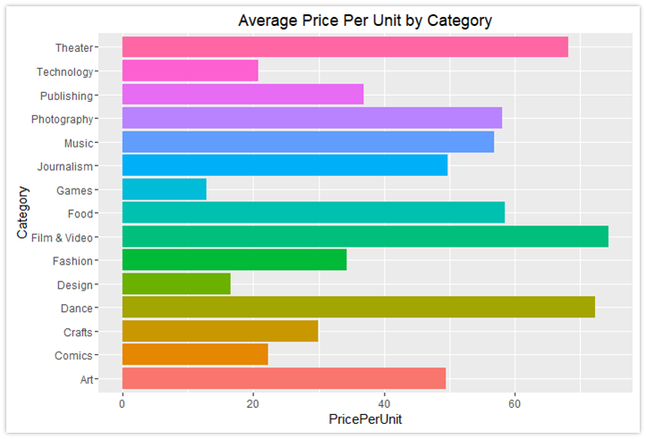

Our analysis found that successful Kickstarters usually have a Mean Price Per Unit (Goal/Backers) of $32.42, although this obviously varies widely across categories. Successful Kickstarters would need at least 187 backers on average, or to ship at least 187 units.

We argue first that potential Kickstarter candidates must know this number for their category and subcategory in order to determine whether it is financially worth it for them to launch a Kickstarter campaign. The average contribution to a Kickstarter campaign is essentially the product’s market price. If the market price is a viable one–that is, their product costs less to produce than the Mean Price Per Unit–then this number should factor into how they structure their campaign. They would be wise to look at the average goal for successful Kickstarters in the relevant category in order to set their goal appropriately, as many failed Kickstarters simply set goals that were above what the market would bear. In addition, the average number of backers per category can help them set their own goals for how many backers they need to get and should inform how they structure their backer levels.

But the bottom line is that the Mean Price Per Unit must be above the cost per unit, or Kickstarter will not be a viable funding source. Then campaign launchers can strategize on how to maximize profits by increasing that difference.

# Presentation Slides

Our presentation slides are available at https://github.com/OwenJaniceVyjayanthiINFM600/Kickstarter-Data-Analysis/blob/master/Kickstart%20your%20way%20to%20success.pptx.

# Contributorship

Project management - Janice Chan

GitHub repository management - Owen Henry

R script/plots

- Data cleaning - Owen Henry
- Remove outliers - Janice Chan
- Time series analysis - Owen Henry
- Successful campaigns analysis - Janice Chan
- Failed campaigns analysis - Vyjayanthi Kamath
- Combining scripts from each contributor - Janice Chan
- Time series plots - Owen Henry
- Mean campaign goals, pledges, backers plots - Vyjayanthi Kamath
- Median campaign goals, pledges, backers plots - Owen Henry
- Refactoring, finalizing R script and plots - Owen Henry

Written portions

- Work plan - Janice Chan
- Gantt chart - Vyjayanthi Kamath
- Data preparation document - Owen Henry
- Written summary
- Audience and decisions - Janice Chan
- Source data and processing - Janice Chan
- Figure/plot - Owen Henry
- Interpretation - Owen Henry
- Persuasive argument to audience re: analysis - Janice Chan
- Persona - team started in class, Janice Chan finalized

Presentation

- Introduction - Janice Chan
- Analysis - Owen Henry
- Recommendations - Vyjayanthi Kamath
- Delivery - all

# Appendix A - Persona

### PERSONA: Adam Ward

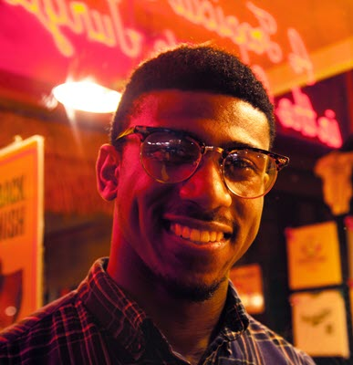

**Name:** Adam Ward

**Age:** 34

**Pronouns:** he/him/his

**Education:** Four-year degree

**Occupation:** Technical Project Manager

**Salary Range:** $85,000 - $100,000 USD/year

**Nationality:** American

> “Walking around to different banks and investors to present a slide deck in person? That’s so old school. The internet has opened up so many opportunities that weren’t there before. It’s up to you to capitalize on them, but that doesn’t mean going in without a plan.”

**Bio:**

Adam is a project manager for a software development company. He and his best friend from college, Michael, have an idea for an app that started because they were tired of going out with friends only to discover that it was a 45 minute wait to get into a restaurant that doesn’t take reservations, or that the bar they wanted to check out is packed full. Their app would allow you to enter the name of the too-full restaurant and search nearby and suggest venues with similar food, ambiance, price points, etc. They want to partner with new restaurants as well so that suggestions can cater to those who want to try something new. However, both of them work very demanding jobs and they don’t have enough free time to work on their dream.

**User Goals:**

- Quit his job to focus on the app full-time
- Build the app and turn it into a startup

**User Needs:**

- Needs to be able to raise funds fairly quickly and, because he has a demanding job, without too much time and effort required.
- Needs to be able to pay rent in Washington, DC, his student loans, car payments, and other living expenses—like food! So, if it doesn’t raise at least a certain amount, it may not be worth it if he doesn’t raise enough to quit his job.
- Wants to be able to create a data-driven campaign for the best chances of success.

**Pain Points:**

- He doesn’t want to have to talk to people to raise money. It takes a lot of time and is very draining for him as an introvert.
- He is not a data analyst, so even though there is a lot of data out there, he finds it a bit overwhelming.
- He’s short on time.

**Beliefs:**

- Success is made, not given. Entrepreneurship is the only way to ensure success.
- Everybody has this problem of crowded restaurants–they’ll definitely want my app!
- I will be in that 1%.

**Biases/Preferences:**

- Digital first - The first question is always, “Can I do it online?”
- Is okay with taking some risk, but prefers they be calculated

**Expertise:**

- As a project manager, he’s pretty comfortable with creating a plan and executing it with a team, managing budgets, and staying on track. This seems to him that it would be like running a business, but he has not actually run a business before.
- He has occasionally supported Kickstarter campaigns, but has never created any type of crowdfunding or fundraising campaign before.

**Personality:**

- Introvert
- Likes to be helpful and share his knowledge
- Deliberate
- Planner

*Photo by Maria Badasian on Unsplash.com, used under a CC0 license*